# DATA 624: PREDICTIVE ANALYTICS Project 1

Gabriel Campos

Last edited March 23, 2024

```r
library(fpp3)
library(dplyr)
library(ggplot2)
library(readxl)
library(tsibble)
library(psych)
library(tidyr)
library(forecast)
```

# Description

This project consists of 3 parts - two required and one bonus and is worth 15% of your grade. The project is due at 11:59 PM on Sunday Apr 11. I will accept late submissions with a penalty until the meetup after that when we review some projects.

## Part A

**ATM Forecast** [ATM624Data.xlsx](https://bbhosted.cuny.edu/bbcswebdav/pid-81630946-dt-content-rid-636012399_1/xid-636012399_1)

In part A, I want you to forecast how much cash is taken out of 4 different ATM machines for May 2010. The data is given in a single file. The variable ‘Cash’ is provided in hundreds of dollars, other than that it is straight forward. I am being somewhat ambiguous on purpose to make this have a little more business feeling. Explain and demonstrate your process, techniques used and not used, and your actual forecast. I am giving you data via an excel file, please provide your written report on your findings, visuals, discussion and your R code via an RPubs link along with the actual.rmd file Also please submit the forecast which you will put in an Excel readable file.

## Part B

Forecasting Power [ResidentialCustomerForecastLoad-624.xlsx](https://bbhosted.cuny.edu/bbcswebdav/pid-81630947-dt-content-rid-636015207_1/xid-636015207_1)

Part B consists of a simple dataset of residential power usage for January 1998 until December 2013. Your assignment is to model these data and a monthly forecast for 2014. The data is given in a single file. The variable ‘KWH’ is power consumption in Kilowatt hours, the rest is straight forward. Add this to your existing files above.

## Part C

BONUS, optional (part or all), [Waterflow_Pipe1.xlsx](https://bbhosted.cuny.edu/bbcswebdav/pid-81630948-dt-content-rid-636015213_1/xid-636015213_1) and [Waterflow_Pipe2.xlsx](https://bbhosted.cuny.edu/bbcswebdav/pid-81630949-dt-content-rid-636015214_1/xid-636015214_1)

Part C consists of two data sets. These are simple 2 columns sets, however they have different time stamps. Your optional assignment is to time-base sequence the data and aggregate based on hour (example of what this looks like, follows). Note for multiple recordings within an hour, take the mean. Then to determine if the data is stationary and can it be forecast. If so, provide a week forward forecast and present results via Rpubs and .rmd and the forecast in an Excel readable file.

## Data Load

https://github.com/GitableGabe/Data624_Data/raw/main/ATM624Data.xlsx

```r
atm_coltype<-c("date","text","numeric")

atm_import<-read_xlsx('ATM624Data.xlsx', col_types = atm_coltype)
# Ommitting Extra Credit as I won't be working on it
# WP1_df<-read_xlsx('Waterflow_Pipe1.xlsx')
# WP2_df<-read_xlsx('Waterflow_Pipe2.xlsx')
```

```r
power_raw<-read_xlsx('ResidentialCustomerForecastLoad-624.xlsx')
```

# Part A

## EDA & Cleanup

```r
head(atm_import%>%
       filter(ATM=="ATM4"))
```

| DATE | ATM | Cash |
| --- | --- | --- |
| 2009-05-01 | ATM4 | 776.99342 |
| 2009-05-02 | ATM4 | 524.41796 |
| 2009-05-03 | ATM4 | 792.81136 |
| 2009-05-04 | ATM4 | 908.23846 |
| 2009-05-05 | ATM4 | 52.83210 |
| 2009-05-06 | ATM4 | 52.20845 |

```r
atm_range<-range(atm_import$DATE)
atm_range[1]
```

```
[1] "2009-05-01 UTC"
```

```r
atm_range[2]
```

```
[1] "2010-05-14 UTC"
```

```r
sapply(atm_import, function(x) sum(is.na(x)))
```

```
DATE  ATM Cash
   0   14   19
```

```r
data.frame(atm_import$DATE[atm_import$Cash %in% NA])
```

| atm_import.DATE.atm_import.Cash..in..NA. |
| --- |
| 2009-06-13 |
| 2009-06-16 |
| 2009-06-18 |
| 2009-06-22 |
| 2009-06-24 |
| 2010-05-01 |
| 2010-05-02 |
| 2010-05-03 |
| 2010-05-04 |
| 2010-05-05 |

[output cut: 9 more lines]

- ATM624Data had attribute type mismatches, and was converted on import.
- Date conversion somehow kept date time as POSIXct
- ATM4 shows values in greater decimals any country, with Dinars being the only Country that uses more than 2 decimals when using its currency, but even the dinar stops at the 100th decimal.
- Date range is 05-01-2009 to 05-14-2010
- we see the count of NAs in ATM is 14 and Cash column is 19
- The NA dates vary and are not exclusive to a specific sequential time period that we can just filter out.
- I am curious about the distribution of cash considering the forecast ask for this project.

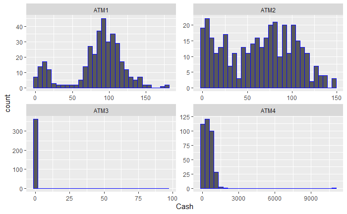

```r
atm_import %>%
  filter(DATE < "2010-05-01", !is.na(ATM)) %>%
  ggplot(aes(x = Cash)) +
    geom_histogram(bins = 30, color= "blue") +
    facet_wrap(~ ATM, ncol = 2, scales = "free")
```

```r
(atm_df <- atm_import %>%
  mutate(DATE = as.Date(DATE)) %>%
   filter(DATE<"2010-05-01")%>%
  pivot_wider(names_from=ATM, values_from = Cash))
```

| DATE | ATM1 | ATM2 | ATM3 | ATM4 |
| --- | --- | --- | --- | --- |
| 2009-05-01 | 96 | 107 | 0 | 776.993423 |
| 2009-05-02 | 82 | 89 | 0 | 524.417959 |
| 2009-05-03 | 85 | 90 | 0 | 792.811362 |
| 2009-05-04 | 90 | 55 | 0 | 908.238457 |
| 2009-05-05 | 99 | 79 | 0 | 52.832103 |
| 2009-05-06 | 88 | 19 | 0 | 52.208454 |
| 2009-05-07 | 8 | 2 | 0 | 55.473609 |
| 2009-05-08 | 104 | 103 | 0 | 558.503251 |
| 2009-05-09 | 87 | 107 | 0 | 904.341359 |
| 2009-05-10 | 93 | 118 | 0 | 879.493588 |

[output cut: 355 more lines]

```r
atm_df<-atm_df%>%
  as_tsibble(index=DATE)
head(atm_df)
```

| DATE | ATM1 | ATM2 | ATM3 | ATM4 |
| --- | --- | --- | --- | --- |
| 2009-05-01 | 96 | 107 | 0 | 776.99342 |
| 2009-05-02 | 82 | 89 | 0 | 524.41796 |
| 2009-05-03 | 85 | 90 | 0 | 792.81136 |
| 2009-05-04 | 90 | 55 | 0 | 908.23846 |
| 2009-05-05 | 99 | 79 | 0 | 52.83210 |
| 2009-05-06 | 88 | 19 | 0 | 52.20845 |

```r
summary(atm_df)
```

```
      DATE                 ATM1             ATM2             ATM3              ATM4
 Min.   :2009-05-01   Min.   :  1.00   Min.   :  0.00   Min.   : 0.0000   Min.   :    1.563
 1st Qu.:2009-07-31   1st Qu.: 73.00   1st Qu.: 25.50   1st Qu.: 0.0000   1st Qu.:  124.334
 Median :2009-10-30   Median : 91.00   Median : 67.00   Median : 0.0000   Median :  403.839
 Mean   :2009-10-30   Mean   : 83.89   Mean   : 62.58   Mean   : 0.7206   Mean   :  474.043
 3rd Qu.:2010-01-29   3rd Qu.:108.00   3rd Qu.: 93.00   3rd Qu.: 0.0000   3rd Qu.:  704.507
 Max.   :2010-04-30   Max.   :180.00   Max.   :147.00   Max.   :96.0000   Max.   :10919.762
                      NA's   :3        NA's   :2
```

```r
atm_df[!complete.cases(atm_df), ]
```

| DATE | ATM1 | ATM2 | ATM3 | ATM4 |
| --- | --- | --- | --- | --- |
| 2009-06-13 | NA | 91 | 0 | 746.49562 |
| 2009-06-16 | NA | 82 | 0 | 372.62361 |
| 2009-06-18 | 21 | NA | 0 | 92.47665 |
| 2009-06-22 | NA | 90 | 0 | 80.64435 |
| 2009-06-24 | 66 | NA | 0 | 90.63657 |

```r
atm_df%>%
  select(DATE,ATM3)%>%
  filter(ATM3>0)
```

| DATE | ATM3 |
| --- | --- |
| 2010-04-28 | 96 |
| 2010-04-29 | 82 |
| 2010-04-30 | 85 |

- Converting `DATE` into a date value made senses type POSIXct may cause future issues.
- Pivoting allowed us to separate the ATM’s categorically and isolate the NAs for removal.
- We are able to see that five entries contain NAs and the dates all reside in June
- ATM3 only has 3 dates with withdrawals 4-28 through 4-30 or 2010, and the distribution plot is arguably a reason to omit this column
- These results also brings to question whether there may be some seasonality that will impact May’s forecasting
- Considering the distribution, I chose to replace the missing values with the median, as the skewed values in ATM 3 & 4 I believe with negatively impact the mean

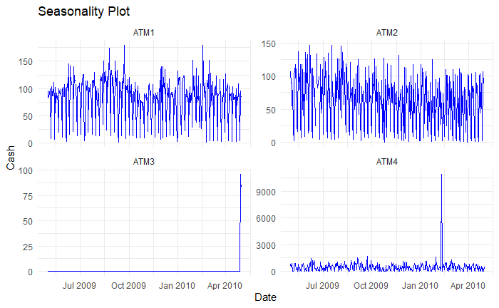

```r
# seasonality
atm_import %>%
  filter(DATE < "2010-05-01", !is.na(ATM)) %>%
  ggplot(aes(x = DATE, y = Cash, col = ATM)) +
    geom_line(color="blue") +
    facet_wrap(~ ATM, ncol = 2, scales = "free_y")+
  labs(title = "Seasonality Plot", x = "Date", y = "Cash") +
    theme_minimal()
```

```r
NA
```

```r
median_value <- median(atm_df[["ATM1"]], na.rm = TRUE)
atm_df[["ATM1"]][is.na(atm_df[["ATM1"]])] <- median_value
median_value <- median(atm_df[["ATM2"]], na.rm = TRUE)
atm_df[["ATM2"]][is.na(atm_df[["ATM2"]])] <- median_value
```

```r
atm_df[!complete.cases(atm_df), ]
```

| DATE | ATM1 | ATM2 | ATM3 | ATM4 |
| --- | --- | --- | --- | --- |

## Forecasts

### ATM1

#### STL Decomposition

The seasonality plot did not show a trend in the long term but a better assessment in weekly interval is likely needed, using resources from [Rob J Hyndman and George Athanasopoulos, Forecasting: Principles and Practice (3rd ed) section 3.6 STL decomposition](https://otexts.com/fpp3/stl.html) I will perform a STL “Seasonal and Trend decomposition using Loess” decomposition of the series. To make it weekly I’ll set the parameter `trend(window = 7)` and the `season(window='periodic')` to impose seasonality element across days of the week.

My reference come directly from the chapter.

```
          us_retail_employment |>
            model(
              STL(Employed ~ trend(window = 7) +
                             season(window = "periodic"),
              robust = TRUE)) |>
            components() |>
            autoplot()
```

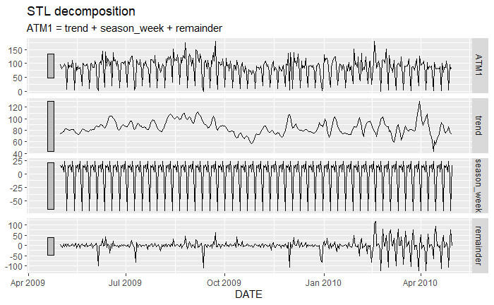

```r
atm1_df <- atm_df %>%
  dplyr::select(DATE, ATM1)

atm1_df %>%
  model(
    STL(ATM1 ~ trend(window = 7) +
                   season(window = "periodic"),
    robust = TRUE)) %>%
  components() %>%
  autoplot()
```

```r
ndiffs(atm1_df$ATM1)
```

```
[1] 0
```

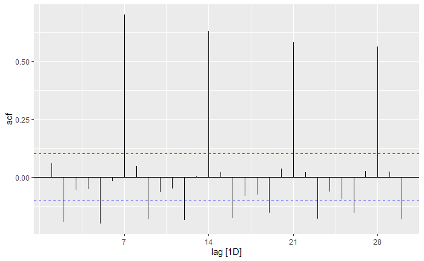

```r
atm1_df %>%
  ACF(ATM1, lag_max = 30) %>%
  autoplot()
```

The STL decomposition wasn’t as telling as I would have liked, however the ACF plot presents lags at 2, 5, and 7. I believe, given the week starts on Sunday, that this represents Monday, Thursday and Saturday as the days with the most lag. 7 has shown the value with the most significant lag. There is a decreasing trend with the ACF plot, and supports that the data is non-stationary would require differencing however $r_ 1's$ small value and the results of the `ndiff()` function, showing the first number of differences as 0, negates that suspicion.

#### ARIMA

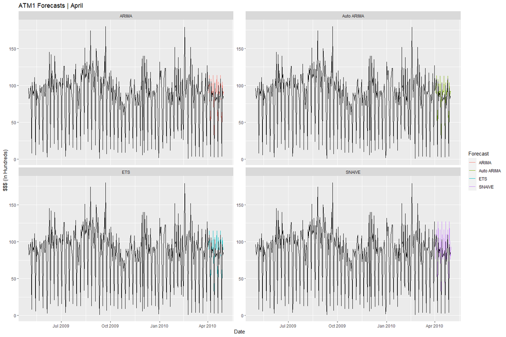

```r
# train
atm1_train <- atm1_df %>%
  filter(DATE <= "2010-04-01")


atm1_fit <- atm1_train %>%
  model(
    SNAIVE = SNAIVE(ATM1),
    ETS = ETS(ATM1),
    ARIMA = ARIMA(ATM1),
    `Auto ARIMA` = ARIMA(ATM1, stepwise = FALSE, approx = FALSE)
  )

# forecast April
atm1_forecast <- atm1_fit %>%
  forecast(h = 30)

#plot
atm1_forecast %>%
  autoplot(atm1_df, level = NULL)+
  facet_wrap( ~ .model, scales = "free_y") +
  guides(colour = guide_legend(title = "Forecast"))+
  labs(title= "ATM1 Forecasts | April") +
  xlab("Date") +
  ylab("$$$ (In Hundreds)")
```

```r
# RMSE
accuracy(atm1_forecast, atm1_df) %>%
  select(.model, RMSE:MAPE)
```

| .model | RMSE | MAE | MPE | MAPE |
| --- | --- | --- | --- | --- |
| ARIMA | 12.61743 | 10.039048 | -85.80727 | 88.87788 |
| Auto ARIMA | 13.03354 | 10.103974 | -98.87311 | 101.77875 |
| ETS | 12.05765 | 9.553739 | -64.45189 | 67.79908 |
| SNAIVE | 16.82670 | 14.517241 | -69.53241 | 76.63865 |

When interpreting the results, the model with the lowest RMSE and MAE value and the MPE and MAPE values closes to zero the best performing. This is true in all cases for ETS indicating it is the best performing.

#### Forecast

** Reference**

```
                      aus_economy |>
                        model(ETS(Population)) |>
                        forecast(h = "5 years") |>
                        autoplot(aus_economy |> filter(Year >= 2000)) +
                        labs(title = "Australian population",
                             y = "People (millions)")
```

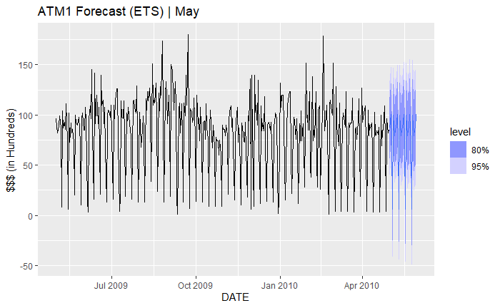

```r
# remade the model from source
atm1_fit_ets <- atm1_df %>%
  model(ETS = ETS(ATM1))

atm1_forecast_ets <- atm1_fit_ets %>%
  forecast(h=30)

atm1_forecast_ets %>%
  autoplot(atm1_df) +
  labs(title = "ATM1 Forecast (ETS) | May",
       y = "$$$ (in Hundreds)")
```

```r
(atm1_forecast_results <-
  as.data.frame(atm1_forecast_ets) %>%
    select(DATE, .mean) %>%
      rename(Date = DATE, Cash = .mean)%>%
        mutate(Cash=round(Cash,2)))
```

| Date | Cash |
| --- | --- |
| 2010-05-01 | 87.05 |
| 2010-05-02 | 100.76 |
| 2010-05-03 | 73.11 |
| 2010-05-04 | 5.74 |
| 2010-05-05 | 100.13 |
| 2010-05-06 | 79.43 |
| 2010-05-07 | 85.60 |
| 2010-05-08 | 87.05 |
| 2010-05-09 | 100.76 |
| 2010-05-10 | 73.11 |

[output cut: 20 more lines]

### ATM2

#### STL Decomposition

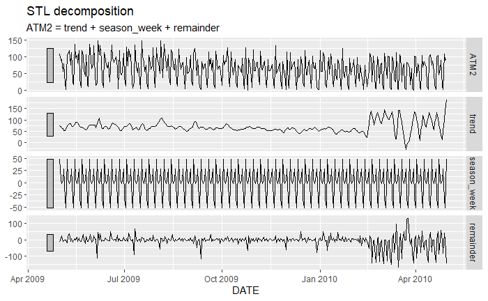

```r
atm2_df <- atm_df %>%
  dplyr::select(DATE, ATM2)

atm2_df %>%
  model(
    STL(ATM2 ~ trend(window = 7) +
                   season(window = "periodic"),
    robust = TRUE)) %>%
  components() %>%
  autoplot()
```

```r
ndiffs(atm2_df$ATM2)
```

```
[1] 1
```

```r
unitroot_ndiffs(atm2_df$ATM2)
```

```
ndiffs
     1
```

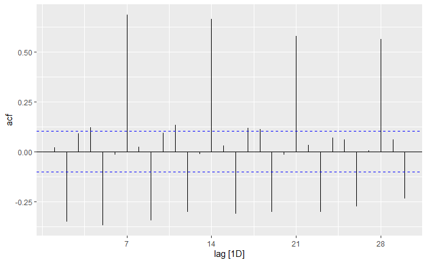

```r
atm2_df %>%
  ACF(ATM2, lag_max = 30) %>%
  autoplot()
```

The approach with ATM2 is a rinse and repeat but in this case differencing is needed and achieved with the below code

```r
atm2_df <- atm2_df %>%
  mutate(diff_ATM2= difference(ATM2))
```

#### ARIMA

Below we again filter out data and identify our best model but include both differenced and non-differenced data.

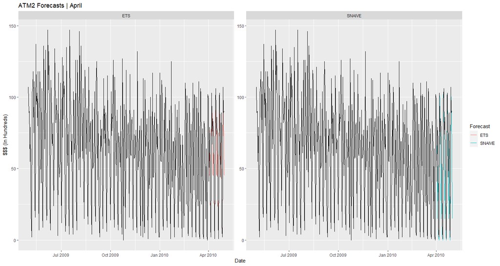

```r
atm2_train <- atm2_df %>%
  filter(DATE <= "2010-04-01")

#run seasonal related models without the differenced data
atm2_fit_nondiff <- atm2_train %>%
  model(
    SNAIVE = SNAIVE(ATM2),
    ETS = ETS(ATM2),
  )

#run models with differenced data
atm2_fit_diff <- atm2_train %>%
  slice(2:336) %>%
  model(
    ETS_diff = ETS(diff_ATM2),
    ARIMA = ARIMA(diff_ATM2),
   `Auto ARIMA` = ARIMA(diff_ATM2, stepwise = FALSE, approx = FALSE)
  )

#forecast_ATM2 April
atm2_forecast_nondiff <- atm2_fit_nondiff %>%
  forecast(h = 30)

#forecast_ATM2 April
atm2__forecast_diff <- atm2_fit_diff %>%
  forecast(h = 30)

#plot
atm2_forecast_nondiff %>%
  autoplot(atm2_df, level = NULL)+
  facet_wrap( ~ .model, scales = "free_y") +
  guides(colour = guide_legend(title = "Forecast"))+
  labs(title= "ATM2 Forecasts | April") +
  xlab("Date") +
  ylab("$$$ (In Hundreds)")
```

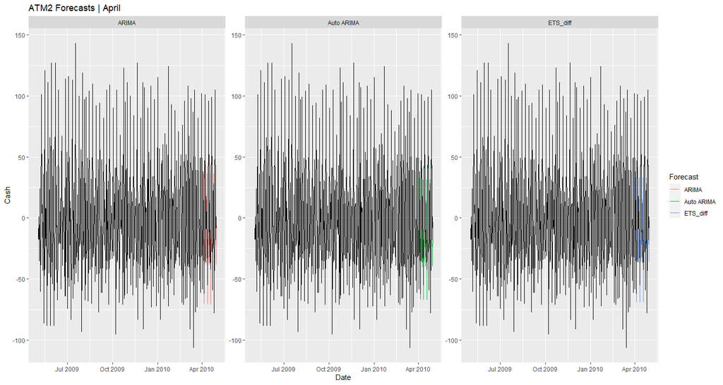

```r
#plot 2
atm2__forecast_diff %>%
  autoplot(atm2_df, level = NULL)+
  facet_wrap( ~ .model, scales = "free_y") +
  guides(colour = guide_legend(title = "Forecast"))+
  labs(title= "ATM2 Forecasts | April") +
  xlab("Date") +
  ylab("Cash")
```

```r
accuracy(atm2_forecast_nondiff, atm2_df) %>%
  select(.model, RMSE:MAPE)
```

| .model | RMSE | MAE | MPE | MAPE |
| --- | --- | --- | --- | --- |
| ETS | 19.01814 | 13.71792 | -29.25415 | 59.44323 |
| SNAIVE | 26.01790 | 16.93103 | 32.27462 | 45.61883 |

```r
accuracy(atm2__forecast_diff, atm2_df) %>%
  select(.model, RMSE:MAPE)
```

| .model | RMSE | MAE | MPE | MAPE |
| --- | --- | --- | --- | --- |
| ARIMA | 26.17208 | 19.47352 | 227.9952 | 238.7448 |
| Auto ARIMA | 25.24158 | 19.05760 | 233.5667 | 241.9152 |
| ETS_diff | 25.00024 | 19.08200 | 220.1288 | 229.0829 |

```r
NA
```

#### Forecast

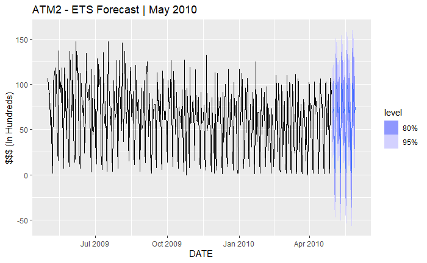

```r
atm2_fit_ets <- atm2_df %>%
  model(
    ETS = ETS(ATM2))

#generate the values
atm2_forecast_ets <- atm2_fit_ets %>%
  forecast(h=30)

#plot
atm2_forecast_ets %>%
  autoplot(atm2_df) +
  labs(title = "ATM2 - ETS Forecast | May 2010",
       y = "$$$ (In Hundreds)")
```

```r
(atm2_forecast_results <-
  as.data.frame(atm2_forecast_ets) %>%
    select(DATE, .mean) %>%
      rename(Date = DATE, Cash = .mean)%>%
        mutate(Cash=round(Cash,2)))
```

| Date | Cash |
| --- | --- |
| 2010-05-01 | 68.35 |
| 2010-05-02 | 74.19 |
| 2010-05-03 | 11.09 |
| 2010-05-04 | 2.14 |
| 2010-05-05 | 101.60 |
| 2010-05-06 | 92.38 |
| 2010-05-07 | 68.98 |
| 2010-05-08 | 68.35 |
| 2010-05-09 | 74.19 |
| 2010-05-10 | 11.09 |

[output cut: 20 more lines]

### ATM3

ATM3 was ultimately omitted, considering the limited date range and skewed distributions. It can be considered when more data is provided.

### ATM4

#### STL Decomposition

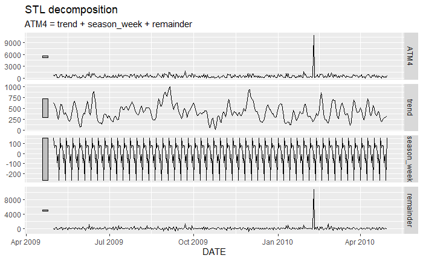

```r
atm4_df <- atm_df %>%
  select(DATE, ATM4)

atm4_df %>%
  model(
    STL(ATM4 ~ trend(window = 7) +
                   season(window = "periodic"),
    robust = TRUE)) %>%
  components() %>%
  autoplot()
```

Considering the variance from the time series, I decided to tranform the data before forecasting using box-cox transformation

#### Box-Cox

**Reference**

[Forecasting Principles and Practice](https://otexts.com/fpp3/transformations.html)

```
      lambda <- aus_production |>
        features(Gas, features = guerrero) |>
        pull(lambda_guerrero)
      aus_production |>
        autoplot(box_cox(Gas, lambda)) +
        labs(y = "",
             title = latex2exp::TeX(paste0(
               "Transformed gas production with $\\lambda$ = ",
               round(lambda,2))))
```

```r
(atm4_lambda <- atm4_df %>%
  features(ATM4, features = guerrero) %>%
  pull(lambda_guerrero))
```

```
[1] -0.0737252
```

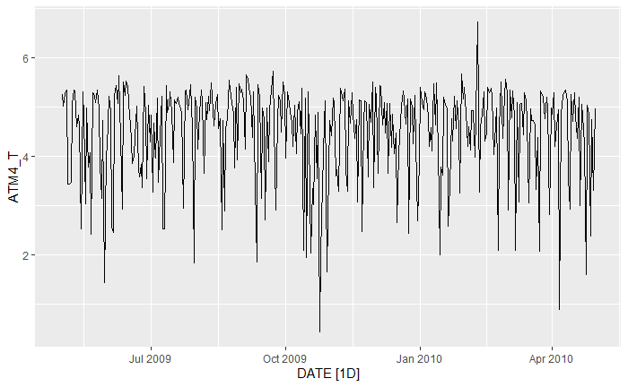

```r
atm4_transformed <- BoxCox(atm4_df$ATM4, lambda = atm4_lambda)

# Extract the transformed data

atm4_df$ATM4_T<-atm4_transformed

#plot
atm4_df%>%
  autoplot(ATM4_T)
```

```r
ndiffs(atm4_df$ATM4)
```

```
[1] 0
```

```r
ndiffs(atm4_df$ATM4_T)
```

```
[1] 0
```

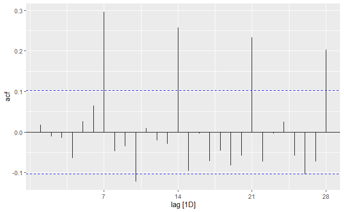

```r
atm4_df %>%
  ACF(ATM4_T, lag_max = 28) %>%
  autoplot()
```

The ACF plot below suggest lags 7 consistently and on 2 other occasions in different periods. Despite the ndiff() function resulting in 0, if believe this does require differencing using the transformed data.

```r
atm4_df <- atm4_df %>%
  mutate(diff_ATM4= difference(ATM4_T))
```